# Coursework Report

*N* removed NAs: 2

*N* removed typo: 1

*N* removed <18: 24

*N* total clean: 123

| Group | *N* | *M*<sub>age</sub> | *M*<sub>rating</sub> |
| --- | --- | --- | --- |
| Control | 63 | 20.79 | 5.98 |
| Experim | 60 | 20.77 | 6.74 |

**Main analysis results**

[interactive chart not shown]

[figure not shown]

[interactive chart not shown]

# Coursework Report

Analysing Data, Spring 2020

# Methods

## Participants

Here are some descritive statistics for the participants age: *M*<sub>age</sub> = 20.74, *SD*<sub>age</sub> = 2.12, *Min*<sub>age</sub> = 18, *Max*<sub>age</sub> = 25, *Range* = 7

## Design

The conceptual hypothesis for this experiment was, ‘does colour influence attractiveness?’.

The independent variable in this experiment was colour (a categorical variable). To operationalise this variable, participants were shown one of two different coloured frames, both of which contained the same picture of a moderately attractive man. Half of the participants were shown the picture in a red frame (experimental condition) while the rest were shown a white frame (control condition), which shows that the variable had two different levels to it. This means that this experiment is an independent measures design. Colour is also the predictor in this experiment as it is the variable that we are manipulating (independent variable).

Attractiveness is the dependant variable in this experiment (a continuous variable). It is also the outcome of this study, as it is the thing that changes due to manipulation of the predictor. To operationalise this variable, an attractiveness scale was implemented, scoring 1-9, with 9 being most attractive, and 1 being the lest attractive. In both the experimental and control groups, the participants were asked to score the picture on this scale, for three standardised questions:

- How attractive do you think this person is?
- How pleasant is this person to look at?
- If I were to meet the person in this picture face to face, I would think he is attractive.

The operational hypothesis of this experiment was, ‘does viewing a different colour frame around an image of a moderately attractive man influence the mean ratings of his attractiveness?’

The statistical analysis test that will be used to test this hypothesis, is the t-test.

# Results

Table 1 shows the overall mean scores of attractiveness in both conditions, while Table 2 shows the means and standard deviations for all three questions in both conditions. Both tables show that the means for the two conditions are relatively similar - 5.96 for the control condition, and 6.74 for the experimental condition. But overall the mean scores for the experimental condition were higher than those in the control condition for all three questions. Therefore, this shows that the participants perceived the man in conjunction with the red frame to be more attractive than when in conjunction with the white frame. This finding is also desplayed in figure 1 below. Overall, these results support the conceptual hypothesis that colour does influence attractiveness.

Table 1 *Overall Mean For Both Conditions*

| Condition | Mean |
| --- | --- |
| control | 5.96 |
| experimental | 6.74 |

Table 2 *Mean and Standard Deviation of Respnses for Each Question in Both Conditions*

| Group | Item 1 *M* | Item 1 *SD* | Item 2 *M* | Item 2 *SD* | Item 3 *M* | Item 3 *SD* |
| --- | --- | --- | --- | --- | --- | --- |
| control | 5.87 | 1.58 | 5.98 | 1.45 | 6.02 | 1.32 |
| experimental | 6.77 | 1.41 | 6.83 | 1.60 | 6.63 | 1.22 |

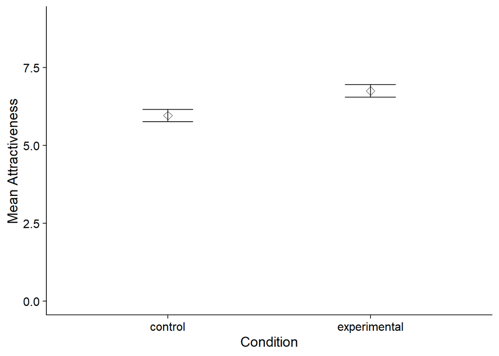

Here is the statistical t-test. The calculated value of t was -5.29. This result is far away from 0 (which assumes that the null hypothesis is true) meaning that it is less likely that the null hypothesis should be accepted. The calculated p-value is also extremely small at < 0.001, meaning that the t-value is extremely unlikely when the null hypothesis is true. Therefore I reject the null hypothesis and accept the alternative hypothesis.

```
##
##  Two Sample t-test
##
## data:  mean_score by GROUP
## t = -5.29, df = 120, p-value = 0.0000005584
## alternative hypothesis: true difference in means is not equal to 0
## 95 percent confidence interval:
##  -1.0821816 -0.4927288
## sample estimates:
##      mean in group control mean in group experimental
##                   5.956989                   6.744444
```

# Discussion

Overall, these results support the conceptual and experimental hypotheses’, and suggest that colour (specifically the colour red) does in fact influence wommen’s perceptions of attractivness, and makes men appear more attractive. This is shown in both Table 1 & 2, along with Figure 1, where the average attractivness ratings for each of the questions in the experimental condition are higher than in the control condition.

This finding supports those of the original paper (Elliot et al., 2010), which also concluded that the colour red did have an effect on womens perceptions of mens attractiveness. The pattern of data above resembles the data from this original study, as the red condition in both resulted in higher attractiveness ratings than the control conditions. This suggests that this effect is real. However, my findings do not correlate with other studies investigating this effect. Researchers such as Peperkoorn et al (2016) and Hesslinger et al (2015) found no significant effect of the colour red on perceived attractiveness, which contradicts the findings from this study. This suggests that the relationship between the colour red and perceived attractivness may not actually be statistically significant.

Despite the fact that this study does support the link between red and perceived attractiveness, overall I do not believe that this so-called ‘red effect’ is real. Firstly due to the limitations of this study, including small sample size, which means that the study lacks generalisability. Moreover, the original study (Ellis el al., 2010), which also supports the red effect, has been criticised for publication bias by Francis (2013), bringing into question the validity and reliability of Ellis’ findings. Furthermore, there is little supporting evidence for this effect. Hesslinger et al. (2015) found that the colour red did have an effect on their dependant variables (perceived attractiveness and perceived status), however it was not statistically significant for either variable. Even when they widened their sample size, they did not find a significant effect. Another study (Peperkoorn et al., 2016) also failed to support the red effect.

Although I don’t believe the red effect is real, I do think that this research question could be further investigated. One way this question could be developed, could be to investigate if different shades of red differ in how they increase perceptions of attraction (e.g. light red, burgundy etc). Similar to this experiment, different groups of women could be shown pictures of the same man, but each group is shown the picture in conjunction with a different red backgound. They would then be asked to rate the man on the same scale used above.

In conclusion, this study clearly shows that there is a statistically significant relationship between the colour red, and women’s perceptions of mens attractiveness. It can clearly be deduced that red makes men appear more attractive to women. However, the lack of external supporting evidence makes me unwilling to accept that this effect is real. Therefore, the ambiguity of this effect leads me to believe that this topic should be subject to further investigation.

# References

Elliot, A. J., Niesta Kayser, D., Greitemeyer, T., Lichtenfeld, S., Gramzow, R. H., Maier, M. A., & Liu, H. (2010). Red, rank, and romance in women viewing men. Journal of Experimental Psychology: General, 139(3), 399–417. https://psycnet.apa.org/doi/10.1037/a0019689

Francis, G. (2013). Publication bias in “Red, rank, and romance in women viewing men,” by elliot et al. (2010). Journal of Experimental Psychology: General, 142(1), 292-296. doi:http://dx.doi.org/10.1037/a0027923

Elliot, A. J., & Maier, M. A. (2013). The red-attractiveness effect, applying the ioannidis and trikalinos (2007b) test, and the broader scientific context: A reply to francis (2013). Journal of Experimental Psychology: General, 142(1), 297-300. doi:http://dx.doi.org/10.1037/a0029592

Hesslinger, V. M., Goldbach, L. & Carbon, C. (2015). Men in red: A reexamination of the red-attractiveness effect. Psychon Bull Rev 22, 1142–1148. https://doi.org/10.3758/s13423-015-0866-8

Peperkoorn, L. S., Roberts, S. C., & Pollet, T. V. (2016). Revisiting the Red Effect on Attractiveness and Sexual Receptivity: No Effect of the Color Red on Human Mate Preferences. Evolutionary Psychology. https://doi.org/10.1177/1474704916673841